# 데이터 과학을 위한 저작도구: Computational Documents

`GitHub` 호스팅

[Tidyverse Korea](https://www.facebook.com/groups/tidyverse/)

2020-03-01

# 1 대쉬보드 [^1] [^2]

**A 12 Step Program to Quick Emailing Plots & Csvs**

1. Basic Layout
   - [`flexdashboard`](https://rmarkdown.rstudio.com/flexdashboard/)
2. Printing Tables, Descriptive Statistics, Model Summaries
   - `printr`, `summarytools::dfSummary`, `stargazer::stargazer`
   - [list of statistic codes](https://rdrr.io/cran/stargazer/man/stargazer_stat_code_list.html)
3. Interactive Datasets
   - `DT`
4. Interactive Plots
   - `highcharter`
   - 지도(`leaflet`), 시계열(`dygraphs`), `ggplots`(`plotly`)
5. Exporting
   - Datasets with `DT`
   - Highcharter Plots
6. CSS basics
7. Branding: Logos, Fonts, Colors
8. Header/Footer
9. **Hosting**
10. Automate-ish (Render + System())
11. Replicate (Render with arguments)
12. Automate or App it (cron, shiny runtime)

# 2 대쉬보드 호스팅

GitHub 저장소에 개발된 대쉬보드를 웹호스팅도 가능하다. 이를 위해서 크게 두가지 작업이 별도로 필요하다.

먼저 `rmarkdown::render_site()` 명령어로 개발된 `flexdashboard` 대쉬보드를 `docs/` 폴더로 배포시킨다.

두번째로 `docs/` 폴더에 담긴 대쉬보드 결과물을 GitHub gh-pages에서 호스팅을 위한 환경 설정을 아래와 같이 수행한다.

1. 기존 Github 저장소에 `gh-pages` 브랜치를 추가시켜 활성화 시킨다.
2. **Source**를 `master branch/docs` 폴더를 지정한다.

마지막으로 두번째와 순서가 바뀌어도 상관이 없다. 즉, `_site.yml`을 작성하여 추가시킨다.

```r
name: "my-website"
output_dir: docs
```

[figure not shown]

대쉬보드 GitHub 호스팅

# 3 대쉬보드 제작

`flexdashboard` 팩키지를 사용해서 대쉬보드 사용법에 맞추어 코드를 작성하고 R 시각화 산출물을 배치시킨다. `.Rmd` 소스코드를 RStudio IDE를 사용할 경우 `Ctrl + Shift + B` 단축키를 사용하여 컴파일 시키거나 다음 명령어를 R 콘솔창에 타이핑하여 완성한다. 한글이 들어간 경우 필히 `encoding = 'UTF-8'`을 인자로 넣어준다.

```r
rmarkdown::render_site(encoding = 'UTF-8')
```

제작된 대쉬보드를 로컬 웹서버를 띄워서 웹브라우저로 확인하고자 하는 경우 다음 명령어로 대쉬보드 웹서버를 띄운다. 그리고 나서 웹브라우저에서 `localhost:8201` 포트를 사용해서 접근하면 대쉬보드 결과물을 확인할 수 있다.

```r
rmarkdown::run("index.rmd", shiny_args = list(host="0.0.0.0",port=8201))
```

# 4 `GitHub` 배포

## 4.1 `gh-pages` 생성

`gh-pages`를 활용하여 정정 웹사이트인 경우 별다른 고민없이 배포할 수 있다. 이를 위해서 GitHub 설정을 해줘야만 한다.

[figure not shown]

`gh-pages` 활성화

## 4.2 GitHub Pages **Source**

대쉬보드 [GitHub 저장소](https://github.com/statkclee/covid-19/) 상단에 보면 **Settings**을 클릭하고 나서, 쭉 아래로 내려가면 `GitHub Pages` 메뉴가 보이고 **Source**를 선택해서 `master branch /docs folder`를 지정한다. 즉, 대쉬보드 호스팅을 위해서 대쉬보드 제작 소스코드 `.Rmd`와 `rmarkdown::render_site(encoding = 'UTF-8')`으로 생성된 `docs/` 폴더 산출물을 이용하여 `gh-pages`에 올려서 서비스하겠다는 얘기가 되겠다.

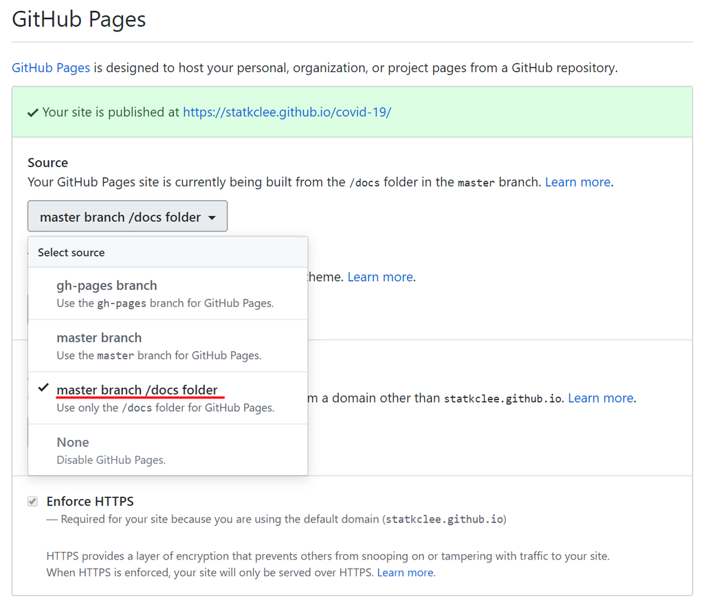

`Source` 지정

## 4.3 코로나19 대쉬보드

[코로나19 대쉬보드](https://statkclee.github.io/covid-19/) 웹사이트에 `gh-pages` 규칙에 맞춰 생성된 URL로 접근하면 호스팅 작업이 마무리 된다.

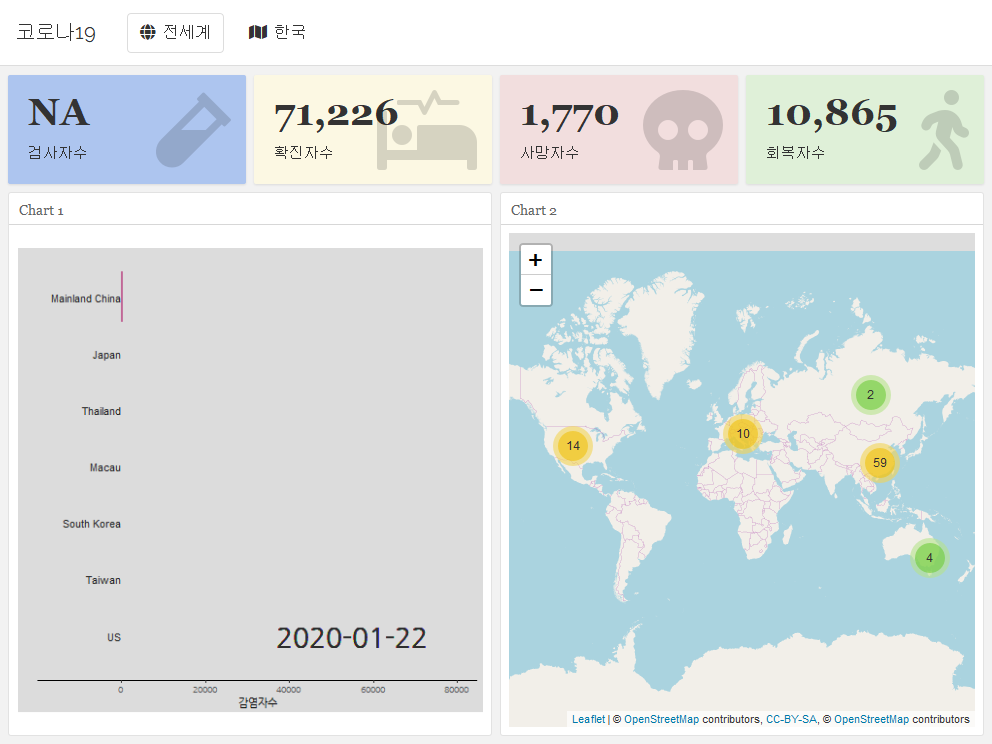

```r
library(webshot)

webshot("https://statkclee.github.io/covid-19/")
```

[^1]: [Marlorie Hughes (2019. 12. 3), “Dashboarding Like a Boss”, DC R Conference](https://www.youtube.com/watch?v=yott4quKN6s)
[^2]: [Sagar Kulkarni (Sep 20, 2019), “Building an HR Dashboard in R using Flexdashboard”, towrds data science](https://towardsdatascience.com/building-an-hr-dashboard-in-r-using-flexdashboard-76d14ed3f32)